# Módulo 7 — Márgenes laborales: margen extensivo, intensivo y elasticidad agregada del trabajo

**Curso complementario · puremacro · mazo Slides07 — mecanismos y economía abierta (semanas 13–14)**

### Objetivos de aprendizaje

Al terminar esta lección podrás:

1. **Descomponer** la varianza de las horas totales en su margen **extensivo** (empleo) e **intensivo** (horas por trabajador): $\mathrm{var}(\Delta\log H)= \mathrm{var}(\Delta\log E)+\mathrm{var}(\Delta\log h)+2\,\mathrm{cov}$, y saber **cuál** de las dos descomposiciones al uso corresponde al «80–90 % extensivo» del mazo.
2. Distinguir la **elasticidad micro** de la oferta de trabajo (finita, la que mide la microeconometría) de la **elasticidad macro** que el modelo necesita, y ver por qué la agregación con trabajo **indivisible** y seguro completo la vuelve **infinita** (Hansen 1985; Rogerson 1988).
3. Construir la **q de Tobin agregada** con datos de balance del sector corporativo no financiero, estimar la respuesta de la **inversión** ante $\Delta\log q$ con **proyecciones locales** y errores estándar **HAC**, y **medir cuán poco explica**: el fracaso empírico clásico de la teoría q.
4. Leer el **precio relativo de la inversión** como el hilo que une q, inversión y trabajo en un mundo **competitivo** (sin cuñas — aunque sí con **costos de ajuste**).

Estos son mecanismos *competitivos*: precios que igualan márgenes, **no cuñas**. Ojo con el matiz: «competitivo» no quiere decir «sin fricciones». La q de Tobin sólo se separa de 1 porque **ajustar el capital cuesta** ($\phi>0$); con $\phi=0$ el mazo muestra que $q_t\equiv 1$ y no habría nada que estimar. Todo corre en Python puro sobre tu **instalación local** de `puremacro` (`pip install puremacro`), con los datos congelados del *bundle*: sin conexión y sin costo.

## 1. Dos márgenes del trabajo

Las **horas totales** trabajadas en la economía se abren en dos factores:

$$H_t = E_t \cdot h_t,\qquad \log H_t = \log E_t + \log h_t,$$

donde $E_t$ es el **número de personas ocupadas** (margen **extensivo**) y $h_t$ son las **horas por trabajador** (margen **intensivo**). En crecimientos, la identidad es exacta:

$$\Delta\log H_t = \Delta\log E_t + \Delta\log h_t.$$

Por lo tanto la varianza de las horas se descompone sin residuo:

$$\mathrm{var}(\Delta\log H)=\underbrace{\mathrm{var}(\Delta\log E)}_{\text{extensivo}} +\underbrace{\mathrm{var}(\Delta\log h)}_{\text{intensivo}} +\underbrace{2\,\mathrm{cov}(\Delta\log E,\Delta\log h)}_{\text{comovimiento}}.$$

**Dos descomposiciones, dos números distintos.** La de arriba deja un tercer término —el comovimiento— que no es de ningún margen, así que las «cuotas» no suman 100 % entre extensivo e intensivo. La literatura (y la lámina del mazo «¿qué margen manda en cada país?») usa la variante **de covarianzas**, que reparte el comovimiento por mitades implícitas y sí suma uno:

$$1=\underbrace{\frac{\mathrm{cov}(\Delta\log E,\Delta\log H)}{\mathrm{var}(\Delta\log H)}}_{\text{cuota extensiva}} +\underbrace{\frac{\mathrm{cov}(\Delta\log h,\Delta\log H)}{\mathrm{var}(\Delta\log H)}}_{\text{cuota intensiva}}.$$

Cuando el mazo dice «en EUA y México el extensivo explica $\sim80$–$90\%$ de la varianza», habla de **esta segunda**. Compararla con la cruda `var(E)/var(H)` es comparar peras con manzanas: abajo imprimimos las dos.

### Por qué importa para el modelo

En el modelo neoclásico competitivo el hogar iguala la **desutilidad marginal del trabajo** con el **salario real** $= $ producto marginal del trabajo. Si ese margen fuera *divisible* y suave, casi todo el ajuste cíclico ocurriría en las **horas por trabajador**. Los datos dicen lo contrario: domina el **empleo**. Ese hecho es la motivación de la **oferta laboral indivisible** (Hansen 1985; Rogerson 1988) y de los modelos con margen extensivo.

> **Nota de datos (leer antes de creerse los números).** El *bundle* no trae series separadas de empleo y horas por trabajador para EUA (no hay `PAYEMS`, `AWHI` ni `HOANBS`; la ruta con datos reales del mazo usa `qna_panel(..., labor=True)` y FRED, y exige red). Así que aquí **simulamos** las dos series con un factor cíclico común y semilla fija. La calibración está **elegida para reproducir** el hecho estilizado del mazo —cuota extensiva de covarianzas $\approx 80\%$ en EUA y México— de modo que ese $80\%$ es un **insumo, no un hallazgo**: lo que el bloque *verifica* es la aritmética (que la identidad de varianzas cierra sin residuo y que las dos descomposiciones difieren), no el hecho empírico. El hecho empírico está en la lámina del mazo, con datos OCDE/BLS. Recordatorio institucional del mazo: en Alemania, España y Francia manda el margen **intensivo** (*Kurzarbeit* y esquemas afines), así que la calibración de abajo no es universal — es la de EUA y México.

```python
rng = np.random.default_rng(20260721)          # SEMILLA declarada: márgenes SIMULADOS
T = 280                                         # 70 años trimestrales
z = np.zeros(T)                                 # factor cíclico común (AR(1))
for i in range(1, T):
    z[i] = 0.70 * z[i - 1] + rng.standard_normal()
z = z / z.std()

# crecimientos trimestrales en % (100·Δlog). Extensivo más volátil que intensivo.
# Coeficientes calibrados para que la CUOTA DE COVARIANZAS extensiva salga ≈ 80 % (mazo).
d_ext = 0.60 * z + 0.34 * rng.standard_normal(T)   # Δlog E : empleo (margen extensivo)
d_int = 0.12 * z + 0.22 * rng.standard_normal(T)   # Δlog h : horas por trabajador (intensivo)
d_tot = d_ext + d_int                              # Δlog H : horas totales (identidad exacta)

v_ext = np.var(d_ext, ddof=1)
v_int = np.var(d_int, ddof=1)
cov   = np.cov(d_ext, d_int, ddof=1)[0, 1]
v_tot = np.var(d_tot, ddof=1)

# cuotas "de covarianzas": suman exactamente 1 porque cov(E,H)+cov(h,H) = var(H)
s_ext = (v_ext + cov) / v_tot
s_int = (v_int + cov) / v_tot

print(f"sd(Δlog E) extensivo   = {d_ext.std(ddof=1):.3f}   (desviación estándar, %)")
print(f"sd(Δlog h) intensivo   = {d_int.std(ddof=1):.3f}")
print(f"corr(ΔE, Δh)           = {np.corrcoef(d_ext, d_int)[0,1]:.2f}")
print(f"var(Δlog H)            = {v_tot:.4f}")
print(f"var(E)+var(h)+2cov     = {v_ext + v_int + 2*cov:.4f}   (identidad)")
print("-" * 62)
print("descomposición CRUDA (tres términos; las dos cuotas NO suman 100 %)")
print(f"  extensivo     var(E)/var(H) = {100*v_ext/v_tot:5.1f} %")
print(f"  intensivo     var(h)/var(H) = {100*v_int/v_tot:5.1f} %")
print(f"  comovimiento  2cov /var(H)  = {100*2*cov/v_tot:5.1f} %")
print("descomposición DE COVARIANZAS (la del mazo; suma 100 %)")
print(f"  extensivo   cov(E,H)/var(H) = {100*s_ext:5.1f} %   ← comparable con el 80–90 % del mazo")
print(f"  intensivo   cov(h,H)/var(H) = {100*s_int:5.1f} %")

assert np.isclose(v_tot, v_ext + v_int + 2 * cov)   # la identidad no tiene residuo
assert np.isclose(s_ext + s_int, 1.0)               # las cuotas de covarianzas sí suman 1
assert v_ext > v_int                                # el extensivo domina
assert cov > 0                                      # los márgenes comueven
assert 0.75 <= s_ext <= 0.90                        # calibración en el rango del mazo (EUA/México)
```

```
sd(Δlog E) extensivo   = 0.657   (desviación estándar, %)
sd(Δlog h) intensivo   = 0.252
corr(ΔE, Δh)           = 0.40
var(Δlog H)            = 0.6257
var(E)+var(h)+2cov     = 0.6257   (identidad)
--------------------------------------------------------------
descomposición CRUDA (tres términos; las dos cuotas NO suman 100 %)
  extensivo     var(E)/var(H) =  68.9 %
  intensivo     var(h)/var(H) =  10.2 %
  comovimiento  2cov /var(H)  =  20.9 %
descomposición DE COVARIANZAS (la del mazo; suma 100 %)
  extensivo   cov(E,H)/var(H) =  79.4 %   ← comparable con el 80–90 % del mazo
  intensivo   cov(h,H)/var(H) =  20.6 %
```

### Lectura

El margen **extensivo** (empleo) explica la mayor parte de la varianza de las horas; el **intensivo** (horas por trabajador) aporta poco por sí solo, y el término de **comovimiento** es positivo (en las expansiones entran personas *y* suben las horas de quienes ya trabajan). Un modelo con trabajo perfectamente divisible pone casi todo el peso en el intensivo: contradice el dato **de EUA y México**.

Fíjate en la brecha entre las dos descomposiciones: la cruda deja ~⅕ de la varianza en un término de comovimiento que no es de nadie, y por eso su cuota extensiva sale ~10 pp por debajo de la de covarianzas. Si comparas tu número con el $80$–$90\%$ del mazo sin decir cuál calculaste, no estás comparando lo mismo. (Regla del curso: ningún segundo momento se publica sin decir cómo se midió.)

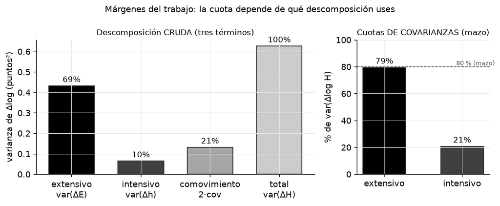

```python
cols = _nbstyle.palette(4)
labels = ["extensivo\nvar(ΔE)", "intensivo\nvar(Δh)", "comovimiento\n2·cov", "total\nvar(ΔH)"]
vals = [v_ext, v_int, 2 * cov, v_tot]

fig, (ax, ax2) = plt.subplots(1, 2, figsize=(9.0, 3.7),
                              gridspec_kw={"width_ratios": [2.1, 1]})
bars = ax.bar(labels, vals, color=[cols[0], cols[2], cols[3], "0.80"],
              edgecolor="0.15", width=0.66)
for b, v in zip(bars, vals):
    ax.text(b.get_x() + b.get_width() / 2, v + 0.01, f"{100*v/v_tot:.0f}%",
            ha="center", va="bottom", fontsize=10)
ax.set_ylabel("varianza de Δlog (puntos²)")
ax.set_title("Descomposición CRUDA (tres términos)", fontsize=10)
ax.axhline(0, color="0.85", lw=0.6)

# la descomposición del mazo: cuotas de covarianzas, que sí suman 100 %
ax2.bar(["extensivo", "intensivo"], [100 * s_ext, 100 * s_int],
        color=[cols[0], cols[2]], edgecolor="0.15", width=0.55)
for xi, si in zip([0, 1], [s_ext, s_int]):
    ax2.text(xi, 100 * si + 1.5, f"{100*si:.0f}%", ha="center", va="bottom", fontsize=10)
ax2.axhline(80, color="0.35", ls="--", lw=0.9)
ax2.text(1.42, 80, "80 % (mazo)", ha="right", va="bottom", fontsize=8, color="0.35")
ax2.set_ylim(0, 100)
ax2.set_ylabel("% de var(Δlog H)")
ax2.set_title("Cuotas DE COVARIANZAS (mazo)", fontsize=10)

fig.suptitle("Márgenes del trabajo: la cuota depende de qué descomposición uses", fontsize=11)
plt.tight_layout()
plt.show()
```

## 2. La elasticidad agregada la fabrica la agregación, no la microeconometría

El RBC necesita una oferta de trabajo muy elástica; la microeconometría mide elasticidades **pequeñas**. Hansen (1985) y Rogerson (1988) resuelven la tensión **sin tocar la micro**.

Con un continuo de individuos $i\in[0,1]$ y preferencias $u(c_{it},h_{it})=\log c_{it}+\mu\frac{(1-h_{it})^{1-\nu}}{1-\nu}$:

- **Trabajo divisible.** Cada quien elige $h$ en el margen. Manteniendo constante la utilidad marginal del consumo, la elasticidad de **Frisch** es $\;\varepsilon^{\text{micro}}=\dfrac{1-\bar h}{\nu\,\bar h}$: finita, y tanto menor cuanto mayor es la curvatura $\nu$ del ocio.
- **Trabajo indivisible + seguro completo.** Se trabaja $\bar h$ o nada, y una lotería con mercados completos asegura el riesgo de desempleo. La utilidad esperada del hogar colectivo colapsa a $\;\log c_t - B\,\theta_t\;$ con $B=\frac{\mu}{1-\nu}\left[1-(1-\bar h)^{1-\nu}\right]$, donde $\theta_t$ es la **fracción empleada**. La desutilidad es **lineal** en $\theta_t$: la oferta agregada de trabajo es **horizontal** y su elasticidad, **infinita** — para cualquier $\nu$, es decir, para cualquier elasticidad micro.

El puente con la sección 1: el margen que se mueve en el modelo indivisible es $\theta_t$, o sea el **extensivo**, exactamente el que domina en el dato de EUA y México.

```python
hbar, mu = 1 / 3, 2.0                 # horas del que trabaja y peso del ocio


def B_indivisible(nu, hbar=hbar, mu=mu):
    """Desutilidad lineal del empleo, B, del hogar con loterías (Hansen–Rogerson)."""
    if np.isclose(nu, 1.0):           # límite log: μ(1-h)^{1-ν}/(1-ν) → μ·log(1-h)
        return -mu * np.log(1 - hbar)
    return mu / (1 - nu) * (1 - (1 - hbar) ** (1 - nu))


print(f"calibración: h̄ = {hbar:.3f} (≈ 1/3 del tiempo disponible), μ = {mu:.1f}")
print(f"{'ν':>5} {'ε Frisch micro (divisible)':>28} {'B (indivisible)':>18} {'ε macro':>10}")
for nu in (0.5, 1.0, 2.0, 4.0):
    eps_micro = (1 - hbar) / (nu * hbar)
    print(f"{nu:5.1f} {eps_micro:28.2f} {B_indivisible(nu):18.3f} {'∞':>10}")

# la elasticidad macro NO depende de ν: la desutilidad es lineal en θ para todo ν
assert all(B_indivisible(nu) > 0 for nu in (0.5, 1.0, 2.0, 4.0))
assert (1 - hbar) / (4.0 * hbar) < (1 - hbar) / (0.5 * hbar)   # más curvatura, menos micro
```

```
calibración: h̄ = 0.333 (≈ 1/3 del tiempo disponible), μ = 2.0
    ν   ε Frisch micro (divisible)    B (indivisible)    ε macro
  0.5                         4.00              0.734          ∞
  1.0                         2.00              0.811          ∞
  2.0                         1.00              1.000          ∞
  4.0                         0.50              1.583          ∞
```

### Lectura

La columna «ε macro» no cambia con $\nu$ **por construcción del argumento**, no por un resultado numérico: al ser $-B\theta_t$ lineal, la condición de primer orden en $\theta_t$ fija el salario, no la cantidad. Ése es todo el truco de Hansen–Rogerson, y es un resultado de **agregación con mercados completos**, no de preferencias exóticas.

Advertencia honesta: la elasticidad infinita es una *idealización*. Con desutilidad **convexa** del empleo y de las horas (Cho–Cooley, el modelo de dos márgenes del mazo) se recupera una solución interior y la elasticidad agregada vuelve a ser finita, aunque mucho mayor que la micro. Y como muestra la lámina de IRF del mazo, ni el trabajo indivisible corrige el problema de fondo del RBC: tras el choque tecnológico **las horas siguen subiendo** en impacto, contra lo que estima Galí (1999).

## 3. La q de Tobin agregada y la inversión

La **q de Tobin** es el valor de mercado del capital instalado dividido entre su costo de reposición. Con costos de ajuste convexos ($\phi>0$ en el mazo), la primera condición de la inversión da $q_t=\lambda_{it}/\lambda_{ct}$ y la **inversión crece con q**. Insistimos en el matiz: si $\phi=0$ entonces $q_t\equiv 1$ y no hay nada que estimar; la fricción de ajuste es **necesaria** para que exista la variable. Lo que no hace falta es una **cuña**.

Aproximamos la **q media** del sector corporativo no financiero con dos series de balance (Financial Accounts / FRED, ya en el bundle):

$$q_t = \frac{\text{valor de mercado del capital accionario (NCBEILQ027S)}} {\text{patrimonio neto a valor de mercado (TNWMVBSNNCB)}}.$$

**Control de unidades (el error clásico):** las dos series están en **millones** de dólares, así que $q$ sale **adimensional y del orden de la unidad**. Si te sale $0.001$ mezclaste millones con miles de millones — comprueba la ficha de FRED, no el nombre.

**Control de muestra:** en las Financial Accounts los niveles de 1945–1951 se publican **sólo anuales** (cuarto trimestre). Si arrancas ahí, `diff()` calcula cambios *anuales* disfrazados de trimestrales y `lp_hac` —que desplaza **filas**, no fechas— trata cinco saltos anuales como si fueran trimestres. Recortamos a **1952Q1 en adelante**, que es donde la serie es genuinamente trimestral, y lo verificamos con un `assert`. (Por eso la mediana de $q$ que verás aquí, $\approx0.95$, difiere del $0.93$ de la lámina del mazo, que no recorta el tramo anual: mismo rango $[0.29,\,1.94]$, distinta muestra. Es exactamente el tipo de diferencia que la **ficha de medición** del curso obliga a declarar.)

Luego medimos cómo responde la **inversión real** (GPDIC1) a un impulso en $\Delta\log q$ con **proyecciones locales** y bandas **HAC** (`lp_hac`), con `n_lags=4` como la figura del mazo.

```python
from puremacro.lp import lp_hac   # verificada con inspect: (df, y, x, horizons, n_lags, controls, alpha)

def _load(fname, col):
    """Lee un CSV congelado de FRED y devuelve [fecha, serie]."""
    return pd.read_csv(DATA / fname, parse_dates=["observation_date"])[
        ["observation_date", col]]

eq  = _load("NCBEILQ027S.csv", "NCBEILQ027S")   # equities (valor de mercado), MILLONES USD
nw  = _load("TNWMVBSNNCB.csv", "TNWMVBSNNCB")   # patrimonio neto (mercado),   MILLONES USD
inv = _load("GPDIC1.csv",      "GPDIC1")        # inversión privada real (miles de mill. 2017)

df = (eq.merge(nw, on="observation_date").merge(inv, on="observation_date")
        .dropna())
df = df[df["observation_date"] >= "1952-01-01"].reset_index(drop=True)  # tramo trimestral
df["q"]      = df["NCBEILQ027S"] / df["TNWMVBSNNCB"]      # q de Tobin agregada
df["dlogq"]  = 100 * np.log(df["q"]).diff()              # Δlog q  (%)
df["loginv"] = 100 * np.log(df["GPDIC1"])                # log inversión (×100)
df = df.dropna().reset_index(drop=True)

# la muestra tiene que ser trimestral CONTIGUA: sin esto, lp_hac mezcla frecuencias
_gap = df["observation_date"].diff().dt.days.dropna()
assert _gap.between(89, 93).all(), "hay saltos no trimestrales en la muestra"

print(f"muestra: {df.observation_date.min():%Y-%m} a {df.observation_date.max():%Y-%m}  "
      f"({len(df)} trimestres contiguos)")
print(f"q: media {df['q'].mean():.2f}, mediana {df['q'].median():.2f}, "
      f"rango [{df['q'].min():.2f}, {df['q'].max():.2f}]  (adimensional: control de unidades OK)")

# proyección local: (loginv_{t+h} - loginv_{t-1}) = a_h + b_h · Δlog q_t + rezagos
irf = lp_hac(df, y="loginv", x="dlogq", horizons=range(0, 17), n_lags=4, alpha=0.10)
print(irf.round(3).head(9).to_string(index=False))

hmax = int(irf.loc[irf["beta"].idxmax(), "h"])
print(f"\nrespuesta máxima en h = {hmax} trimestres: "
      f"{irf['beta'].max():.2f}% de inversión por 1% de Δlog q")

# ¿CUÁNTO explica q? La teoría dice: estadístico SUFICIENTE. El dato dice otra cosa.
d_inv = 100 * np.log(df["GPDIC1"]).diff()
_c = pd.DataFrame({"x": df["dlogq"], "y": d_inv}).dropna()
r2_0 = np.corrcoef(_c["x"], _c["y"])[0, 1] ** 2                     # contemporáneo
_h = pd.DataFrame({"x": df["dlogq"],
                   "y": df["loginv"].shift(-hmax) - df["loginv"].shift(1)}).dropna()
r2_h = np.corrcoef(_h["x"], _h["y"])[0, 1] ** 2                     # al horizonte del pico
print(f"R² bivariado, crecimiento contemporáneo de la inversión sobre Δlog q : {r2_0:.3f}")
print(f"R² bivariado, respuesta acumulada a h = {hmax}                        : {r2_h:.3f}")
print(f"sd(Δlog q) = {df['dlogq'].std():.1f}%  →  un choque de 1 sd mueve la inversión "
      f"{irf['beta'].max()*df['dlogq'].std():.1f}% en el pico")

assert (irf["beta"] > 0).sum() >= 12      # el SIGNO que predice la teoría q sí aparece
assert irf.loc[irf["h"] == hmax, "lo"].item() > 0   # el pico es significativo (banda 90%)
assert r2_0 < 0.10                        # ...pero q NO es un estadístico suficiente
```

```
muestra: 1952-04 a 2026-01  (296 trimestres contiguos)
q: media 0.98, mediana 0.95, rango [0.29, 1.94]  (adimensional: control de unidades OK)
 h   beta    se      t     lo    hi
 0 -0.047 0.030 -1.570 -0.097 0.002
 1  0.099 0.043  2.300  0.028 0.170
 2  0.230 0.049  4.736  0.150 0.310
 3  0.340 0.059  5.746  0.243 0.437
 4  0.351 0.061  5.783  0.251 0.451
 5  0.365 0.073  4.998  0.245 0.486
 6  0.350 0.071  4.897  0.232 0.467
 7  0.264 0.067  3.957  0.154 0.374
 8  0.255 0.073  3.485  0.135 0.375

respuesta máxima en h = 5 trimestres: 0.37% de inversión por 1% de Δlog q
R² bivariado, crecimiento contemporáneo de la inversión sobre Δlog q : 0.009
R² bivariado, respuesta acumulada a h = 5                        : 0.099
sd(Δlog q) = 8.4%  →  un choque de 1 sd mueve la inversión 3.1% en el pico
```

### Lectura de la respuesta: el signo sí, la suficiencia no

**Lo que sale bien.** El perfil tiene el signo que predice la teoría: un aumento de $\Delta\log q$ eleva la inversión de forma acumulativa, el efecto crece durante poco más de un año y luego decae, y el pico es significativo al 90 % con bandas HAC. Cuando el mercado valora el capital instalado por encima de su costo de reposición, conviene instalar más capital.

**Lo que sale mal, y es el punto de la lámina del mazo.** La teoría q no dice sólo «signo positivo»: bajo Hayashi (1982), $q$ es un **estadístico suficiente** para la inversión — nada más debería importar. El $R^2$ que acabas de imprimir lo desmiente: en el contemporáneo $q$ explica alrededor del **1 %** del crecimiento de la inversión, y ni siquiera al horizonte del pico llega a la décima parte. **La relación es débil**: es el fracaso empírico clásico de la teoría q, no su confirmación. Un coeficiente estadísticamente significativo con $R^2\approx 0.01$ es exactamente eso.

El mazo ofrece tres diagnósticos, y ninguno es «el mercado se equivoca»:

1. **Intangibles fuera del denominador.** El costo de reposición del balance omite el capital intangible; la *total q* de Peters–Taylor (2017) recupera buena parte del poder predictivo. Gutiérrez y Philippon (2017) ligan la brecha inversión–q a concentración e intangibles.
2. **No convexidades e inacción.** Si los costos de ajuste no son convexos, la relación lineal q–inversión se rompe: la microevidencia muestra un pico de inacción en cero y episodios de inversión $>20\%$, no ajuste suave.
3. **Agregación.** Con el *capex* de unos pocos *hyperscalers* y valoraciones bursátiles concentradas (2023–25), ¿qué información lleva una q **agregada**?

Dos advertencias de medición, además. El numerador y el denominador de $q$ son del sector **corporativo no financiero**, mientras que `GPDIC1` es la inversión privada real **total** (incluye residencial e inventarios): hay desalineación de universo, y una versión más limpia usaría `PNFI/GDP` como en el ejercicio del mazo. Y `lp_hac` **ya acumula** (regresa $y_{t+h}-y_{t-1}$), por eso pasamos el **nivel** $100\log(\texttt{GPDIC1})$ y no su diferencia: si pasas la diferencia, estimas la respuesta del *crecimiento*, que es otra cosa.

```
PIRIC (inversión TOTAL / consumo): 4.76 → 0.88   factor 5.4× más barato; -2.18% anual, 78 años (1947–2024)
comparación del mazo — PERIC (EQUIPO / consumo, Fisher 2006): factor ≈41 desde 1947,
  ≈4.8% anual. El equipo se abarata MUCHO más rápido que la inversión total,
  que incluye estructuras y residencial. PERIC no viene en el bundle offline.
```

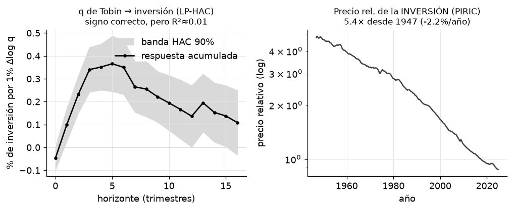

```python
# --- El hilo: precio relativo de la INVERSIÓN (PIRIC), no del equipo (ése es PERIC) ---
pir = pd.read_csv(DATA / "PIRIC.csv", parse_dates=["observation_date"]).dropna()
yrs = pir["observation_date"].dt.year + (pir["observation_date"].dt.month - 1) / 12
p0, p1 = pir["PIRIC"].iloc[0], pir["PIRIC"].iloc[-1]
años = (pir["observation_date"].iloc[-1] - pir["observation_date"].iloc[0]).days / 365.25
tasa = 100 * np.log(p1 / p0) / años
print(f"PIRIC (inversión TOTAL / consumo): {p0:.2f} → {p1:.2f}   "
      f"factor {p0/p1:.1f}× más barato; {tasa:.2f}% anual, {años:.0f} años "
      f"({pir.observation_date.min():%Y}–{pir.observation_date.max():%Y})")
print("comparación del mazo — PERIC (EQUIPO / consumo, Fisher 2006): factor ≈41 desde 1947,")
print("  ≈4.8% anual. El equipo se abarata MUCHO más rápido que la inversión total,")
print("  que incluye estructuras y residencial. PERIC no viene en el bundle offline.")

fig, (a1, a2) = plt.subplots(1, 2, figsize=(8.6, 3.6))

# (a) respuesta de la inversión a Δlog q, con banda HAC 90%
a1.axhline(0, color="0.85", lw=0.6)
a1.fill_between(irf["h"], irf["lo"], irf["hi"], color="0.85", label="banda HAC 90%")
a1.plot(irf["h"], irf["beta"], color=cols[0], lw=1.6, marker="o", ms=3,
        label="respuesta acumulada")
a1.set_xlabel("horizonte (trimestres)")
a1.set_ylabel("% de inversión por 1% Δlog q")
a1.set_title(f"q de Tobin → inversión (LP-HAC)\nsigno correcto, pero R²≈{r2_0:.2f}", fontsize=10)
a1.legend(loc="upper right")

# (b) precio relativo de la inversión: caída secular (escala log)
a2.plot(yrs, pir["PIRIC"], color="0.25", lw=1.5)
a2.set_yscale("log")
a2.set_xlabel("año")
a2.set_ylabel("precio relativo (log)")
a2.set_title(f"Precio rel. de la INVERSIÓN (PIRIC)\n{p0/p1:.1f}× desde 1947 ({tasa:.1f}%/año)",
             fontsize=10)

plt.tight_layout()
plt.show()
```

### El hilo competitivo — y una precisión de nomenclatura que el mazo subraya

El **precio relativo de la inversión** cae de forma secular: cada dólar de inversión compra cada vez más capital efectivo. Es progreso técnico *incorporado* en el capital, à la Greenwood–Hercowitz–Krusell (1997). Ese abaratamiento es una fuerza de demanda de inversión que **eleva la q deseada** y, al cambiar la relación capital/trabajo, reacomoda también los **márgenes laborales**.

> **`PIRIC` ≠ `PERIC`.** `PIRIC` es el precio de la **inversión total** relativo al consumo (la serie del bundle, la que acabas de graficar). `PERIC` es el del **equipo**, y es la que usan Greenwood–Hercowitz–Krusell (1997), Fisher (2006) y Justiniano–Primiceri– Tambalotti (2010) para los choques IST. No son intercambiables: el equipo cae un factor $\approx41$ desde 1947 ($\approx 4.8\%$ anual), la inversión total apenas un factor $5$ ($\approx 2.2\%$ anual), porque el agregado arrastra estructuras y vivienda, que casi no se abaratan. Si necesitas el hecho de GHK/Fisher, la serie es `PERIC`, y exige red: no está en el bundle offline. La identificación IST con `PERIC` está en la lección 10.

Tres piezas — márgenes del trabajo, q de Tobin, precio relativo de la inversión — encajan en un solo relato **competitivo**: precios que igualan márgenes, **sin cuñas**. Con fricciones sí: sin costos de ajuste del capital no hay q que estimar.

## 4. Preguntas para pensar

1. **¿Por qué domina el margen extensivo?** El empleo (entrar y salir del trabajo) es más volátil que las horas por trabajador. ¿Qué lo explica —contratos, semana laboral estándar, fatiga, costos fijos de emplear— y qué le exige eso a un modelo con oferta laboral suave? ¿Y por qué en Alemania, España y Francia manda el **intensivo**?
2. **Elasticidad micro vs macro.** Con $\bar h=1/3$ y $\nu=4$ la elasticidad de Frisch micro es $0.5$, compatible con la microeconometría. ¿Por qué la elasticidad **agregada** no hereda ese $0.5$ bajo trabajo indivisible? ¿Qué supuesto —la lotería, el seguro completo, o la indivisibilidad— hace todo el trabajo, y cuál de los tres te parece más frágil?
3. **q media vs q marginal.** Medimos la q *media* (balance del sector). La teoría habla de la q *marginal*. ¿Bajo qué supuesto (Hayashi 1982) coinciden, y qué hace ese supuesto cuando el capital intangible no está en el balance?
4. **¿Por qué el $R^2$ es tan bajo?** Ordena los tres diagnósticos del mazo (intangibles, no convexidades, agregación) por cuánto crees que explican la brecha, y di qué dato pediría cada uno para distinguirse de los otros dos.
5. **¿Endogeneidad?** $\Delta\log q$ y la inversión pueden responder a un mismo choque. ¿La proyección local con controles rezagados basta para leer $\beta_h$ como respuesta causal, o qué instrumento buscarías?

## 5. Explora con IA

Prueba esto con el tutor sin conexión (o cualquier asistente de IA):

- "¿Por qué el margen extensivo del trabajo es más volátil que el intensivo, y qué modelo lo captura?"
- "Explica en una frase el teorema de Hayashi (1982): ¿cuándo q marginal = q media?"
- "¿Por qué la q agregada casi no predice la inversión, si la teoría dice que es un estadístico suficiente?"

```python
print(tutor("En una frase: ¿por qué la inversión crece con la q de Tobin en el modelo competitivo?"))
```

[output not shown]

**Resumen.** Descompusimos la varianza de las horas de dos maneras y vimos que el margen **extensivo** (empleo) domina al **intensivo** (horas por trabajador) en EUA y México —el hecho que motiva la oferta laboral indivisible—, con la advertencia de que la cuota cambia ~10 pp según qué descomposición uses. Vimos por qué la **elasticidad agregada** del trabajo la fabrica la **agregación** (Hansen–Rogerson: cualquier elasticidad micro es compatible con una macro infinita) y no la microeconometría. Construimos la **q de Tobin agregada** con datos de balance y, con **proyecciones locales HAC** (`lp_hac`), obtuvimos el **signo** que predice la teoría q — pero un $R^2$ que la desmiente como estadístico suficiente: **la relación es débil**, el fracaso empírico clásico. El **precio relativo de la inversión** (`PIRIC`; el del equipo es `PERIC`), en caída secular, es el hilo que une q, inversión y trabajo en un mundo **competitivo** — sin cuñas, aunque con costos de ajuste.

**Siguiente módulo:** la lección **10 — utilización variable, costos de ajuste del capital y q de Tobin** (`10_b1_capital_ajuste_es`), que sigue en este mismo bloque de las semanas 13–14 del mazo Slides07 y toma en serio los dos ingredientes que aquí dimos por sentados: que los servicios de capital son $u_t K_t$ y no $K_t$, y que instalar capital cuesta. Después, la lección **10b** lleva estos mecanismos a la economía pequeña y abierta.

(La contabilidad del ciclo económico con cuñas —la BCA— ya la vimos antes, en la lección 04b de la semana 8; esta lección es el paso *posterior*, no el previo.)